# Final Paper

STOR 320.01 Group 2

April 28, 2025

# INTRODUCTION

Music is a constant presence in our lives. It’s on our social media, in grocery stores, and in our homes. Whether we’re tuning in intentionally or it’s just background noise, music is intertwined into our daily lives. One of the biggest platforms delivering this nonstop soundtrack is Spotify. Over 675 million users listen to Spotify monthly, making it one of the largest music streaming services. Claiming over 30% of the music streaming market share, Spotify is a major player in shaping what we hear. Artists participate in this market by releasing tracks of various genres, lengths, energy levels, and more, all trying to make it to the billboards.

The year 2022 was a major one for music. Harry Styles’ *As It Was* topped Spotify’s global streams, which sparked our curiosity about what exactly contributes to a song’s popularity and whether audio features can help predict it. Our group is interested in whether these popular outcomes on Spotify are reflected through measurable audio characteristics. Specifically, we want to explore whether a track’s popularity can be predicted based on a combination of its genre and audio traits and how those features help define or differentiate genres from one another.

We narrowed these curiosities into two analysis questions:

**Question 1: Which classification model best predicts genre using features of the dataset?**

**Question 2: How can we best predict a track’s popularity based on its genre and other music features?**

The first question stems from the dominating role genre plays in streaming success. Categories like pop, hip-hop, and rock tend to be the most streamed and popular genres, but what distinguishes them in terms of music features? Music features vary greatly through genres, and by attempting to classify songs through music features, we can analyze which features are popular amongst which genres. This analysis, in turn, will help us better understand what makes one genre different from another, or if there are features that can distinguish genres, which would be worth looking into.

The second question builds on the first by shifting to prediction. While genre is often assumed to be a primary predictor of popularity, we’re investigating whether it’s truly the most important factor or if other musical features, which are typically overlooked, play a stronger role. Audio traits like energy, tempo, and instrumentalism might also offer insights into what makes a track go viral or widely streamed for specific genres.

Through our analysis, we hope to uncover some of the unnoticed patterns behind what makes songs popular. Whether you’re an artist, a producer, or just someone who loves music, understanding these dynamics might change the way you listen to your favorite songs in the future.

# DATA

This dataset is a sample of music tracks available on Spotify. It does not contain all Spotify songs, of course, but it does contain over one hundred thousand songs. These songs are diverse in quality, making this an intriguing dataset. Each observation represents a single track that can be found on Spotify. Each column within an observation represents an important value correlating with key information. This includes values about the artist of the track, the album name, the Spotify ID for the track, and many other key data points. In total, this dataset contains 114,000 observations, 1,000 observations from 114 genres.

Maharshi Pandya scraped the data we used in our dataset using Python and the Spotify Web API. This data collection was performed on October 20th, 2022, and made available on October 22nd, 2022. We then took this dataset from Kaggle and decided to focus on several key variables: *duration*, *danceability*, *genre*, and *popularity*. With one of our questions exploring which music feature(s) can best predict a track’s popularity, we also paid attention to most of the other variables: *energy, key, loudness, mode, speechiness, acousticness, instrumentalness, liveness, valence, tempo, and time signature.* The original *duration* variable reflected the track length in milliseconds, but we converted these values to minutes as we believed this unit was a lot easier to understand and visualize. Based on a combination of tempo, rhythm stability, beat strength, and overall regularity, a danceability score is calculated ranging from 0.0 (least danceable) to 1.0 (most danceable). *Energy* is a measure from 0.0 to 1.0 and reflects the activity and intensity of a track. So, more energetic tracks (higher values) will feel noisy, fast, and loud, and vice versa. The *key* of a track is another variable we analyzed. The value is an integer that maps to pitches using standard pitch class notation. For example, 0 = C, 2 = D, and if no key was detected, -1 was the assigned value. *Loudness* represents the overall volume of a track in decibels (dB). *Mode* indicates the modality of a track, whether the track is major (1) or minor (0). The *speechiness variable* (0.0-1.0) shows the presence of spoken words in a track. This means that higher scores indicate that the track has more spoken words. Tracks with a *speechiness* score greater than 0.66 are made entirely of spoken words, while tracks with a *speechiness* score below 0.33 are either music or other non-speech-like tracks. Tracks with a score between 0.33 and 0.66 may contain both music and speech, either layered or in sections. *Acoustiness* is a confidence measure, also from 0.0 to 1.0, and the greater the value, the more confident we can be that a track is acoustic. Similarly, *instrumentalness* predicts whether or not a track contains vocals and is measured from 0.0 to 1.0. As this value gets closer to 1.0, it represents greater confidence that a track contains no vocal content. *Liveness* (0.0-1.0) is a variable that determines if a track was recorded in the presence of an audience. If this value is above 0.8, there is a strong likelihood that a track was recorded live. *Valence* is yet another variable measured from 0.0 to 1.0, and it reflects the positivity of a track. Higher *valence* tracks sound more positive (cheerful, happy, etc.) while lower *valence* tracks sound more negative (sad, angry, etc.). *Tempo* is the average pace of a track in beats per minute (BPM). *Time signature* (meter) is a notation that specifies the number of beats in each measure (bar). This value ranges from 3 to 7 (3/4, 7/4, etc.). The *popularity* column is a score from 0-100 (least popular to most popular). An algorithm calculates this score by taking the total number of plays a track has had and also factoring in the recency of those plays. So, as a general explanation, songs that are being played frequently at the time of data collection will have a higher popularity when compared to songs that were played just as frequently, albeit at a time before the point of collecting data. Another thing to note is that this value rates duplicate tracks independently from one another. Below is a box plot of the popularity score for the 15 genres we used in our final data analysis (more on the genre variable in the next paragraph).

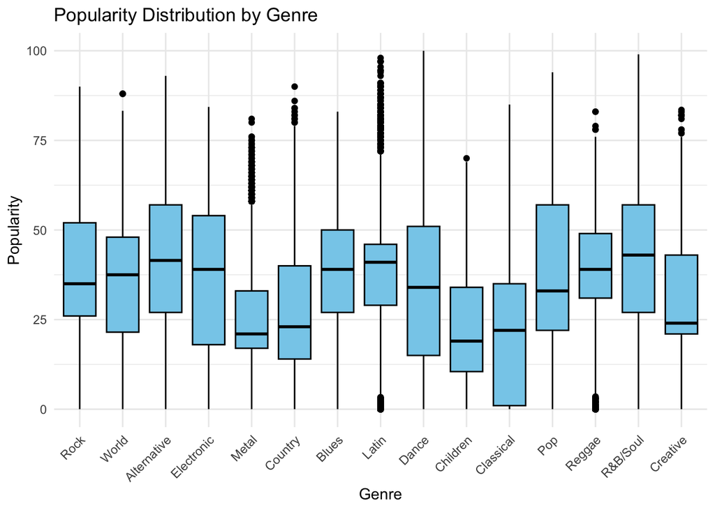

The *genre* variable took the most effort to prepare for our analysis. For most of these variables, we did not have to do anything to them as they could already be used in our code to draw conclusions. Only the *duration* variable had to be altered, and even then, we only performed a simple conversion to convert the units from milliseconds to minutes. However, the *genre* variable posed a big problem for our analysis. There were 114 different genres in this dataset. If we wanted to compare variables like *popularity, danceability,* or *duration* across genres, we would have to find a way to condense the genre variable to have fewer unique values. We did not want to remove genres entirely, as this would remove a large proportion of the data from the dataset and could create false trends in the data that would not arise had we looked at the data as a whole. Ultimately, we decided to combine all 114 genres into just 15 new umbrella genres. This had its drawbacks, of course, combining genres meant that we would lose some trends that would exist if we looked at all 114 genres individually. Nevertheless, this was the best solution to the problem as it allowed us to keep all of the data while also being able to compare other variables across genres. To combine genres, we wanted to be able to defend our new genre groupings. So, we looked at numerous sources online and ultimately settled on a website, [Music Genres List](https://www.musicgenreslist.com/), that was attempting to build a definitive list of music genres based on feedback and discussions from internet users around the world. This site was created in 2009, and it contained 93 of the 114 music genres from our dataset. After taking those 93 genres and sorting them into their respective categories, we still had 21 more genres to sort. From there, we used a combination of logical reasoning and further internet exploration to either add these genres to existing categories or create new categories. In the end, we were able to have just 15 new genres, and naturally, not all of the genres perfectly fit together, but for the most part, all genres in each new category shared some level of similarity with one another. The 15 new genres we had were: *Alternative, Electronic, Metal, Country, [Blu](https://college.berklee.edu/guitar/news/guitar-playing-styles-to-explore-and-master)[es](https://www.britannica.com/art/blues-music), [Latin](https://en.wikipedia.org/wiki/M%C3%BAsica_popular_brasileira), Dance, Children, [Class](https://www.belledorm.co.uk/blog/the-best-music-to-fall-asleep-to)[ical](https://spiritlive.ca/2021/02/24/4-genres-of-music-that-help-with-studying), Reggae, Rock, [R&B/Soul](https://music.stackexchange.com/questions/3827/what-is-groove), [Po](https://thriveworks.com/blog/3-types-music-can-improve-your-life)[p](https://www.allmusic.com/style/show-tunes-ma0000002852), Creative, and World.*. See the table below to see the 114 original genres and the 15 new genres that were developed.

| Umbrella Genre | Original Genres |
| --- | --- |
| Alternative | alt-rock, alternative, emo, goth, grunge, punk, punk-rock |
| Electronic | ambient, chill, drum-and-bass, electronic, idm, industrial |
| Metal | black-metal, grindcore, heavy-metal, metal, metalcore |
| Country | bluegrass, country, honky-tonk, folk |
| Blues | blues, jazz, guitar, sad, gospel |
| Latin | brazil, forro, latin, latino, pagode, reggaeton, salsa, samba, sertanejo, spanish, tango, mpb |
| Dance | breakbeat, chicago-house, club, dance, deep-house, detroit-techno, dubstep, edm, electro, garage, hardcore, hardstyle, house, minimal-techno, progressive-house, techno, trance |
| Children | children, kids |
| Classical | classical, opera, piano, romance, sleep, study |
| Reggae | dancehall, dub, reggae, ska |
| Rock | death-metal, hard-rock, j-rock, psych-rock, rock, rock-n-roll, rockabilly, singer-songwriter, songwriter, trip-hop, acoustic |
| R&B/Soul | disco, funk, r-n-b, soul, groove, hip-hop, party |
| Pop | indie-pop, j-pop, k-pop, pop, pop-film, power-pop, synth-pop, happy, show-tunes, disney, comedy |
| Creative | new-age, indie |
| World | world-music, turkish, british, french, german, iranian, swedish, malay, afrobeat, cantopop, indian, mandopop, j-idol, anime, j-dance |

When we were completing our Exploratory Data Analysis, we encountered a problem with the artists variable. When a track had a collaboration, meaning two or more artists were credited in this dataset for one track, these collaborations were counted as unique artists. Essentially, they were being seen as one unique name, and thus, the data from these rows wasn’t being attributed to either artist. For example, a track with an artist value of “Jason Mraz;Colbie Caillat” would make Jason Mraz;Colbie Caillat a new artist to assign the row values to. So, to resolve this problem, we had to split the artist columns, separating by “;” for collaborations, so as not to create new, unique artists. The Spotify dataset we selected for our project contains a multitude of variables for us to explore. With 114 original genres and 114,000 observations, this dataset divulges critical information about *duration, energy, popularity*, and *danceability*, enabling us to develop significant relationships and trends in music, particularly amongst genres. To do so, we had to lump the genres together into just 15 combined genres to be able to comprehend the data as we created predictive models and graphs. Overall, this data is a valuable resource to analyze meaningful trends within Spotify music.

# RESULTS: Question 1

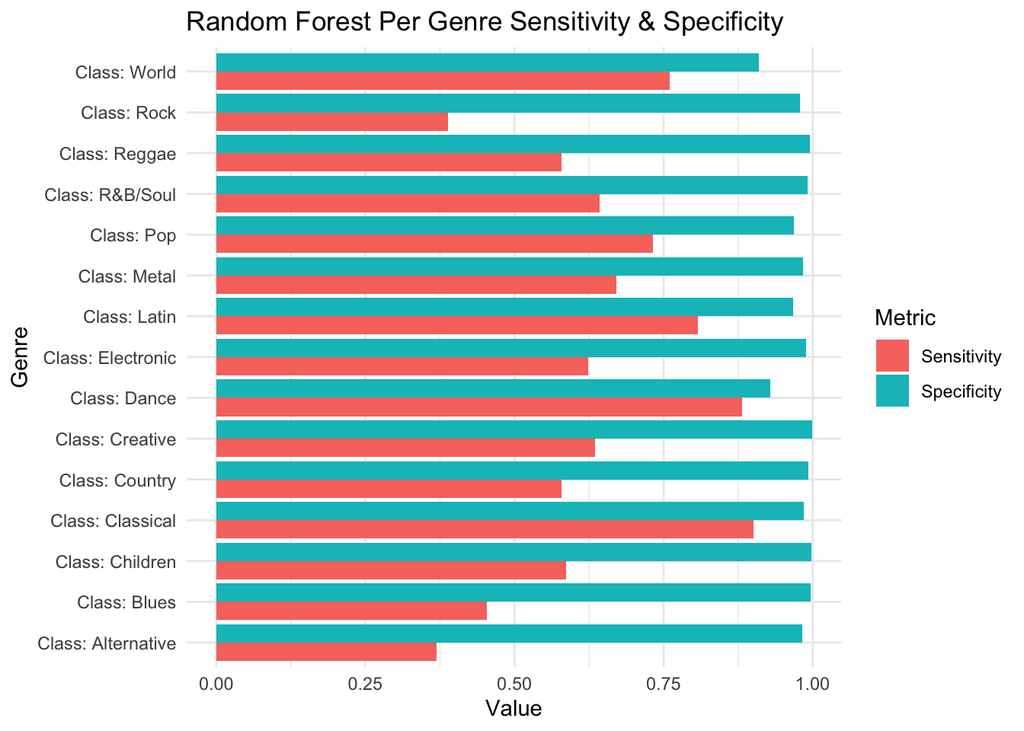

Lastly, we used the **k-nearest neighbors cross-validation** method to check whether or not the relationship between features is strong enough to predict genres. We used a confusion matrix to output the results, showcasing which genres have the clearest patterns, high classification rates, and overlap with others. The model had an accuracy of 63.65%, which was a lot higher than both the **multinomial models**, but lower than the **random forest model**, suggesting that the model does capture real patterns. Genres like *classical* and *dance* had both high sensitivity and high specificity, showing strong and distinctive patterns given all of the music features. Other genres were harder to identify, like *rock* and *alternative*, due to the low sensitivity and high specificity.

```
## Best k = 1 → accuracy = 0.637
```

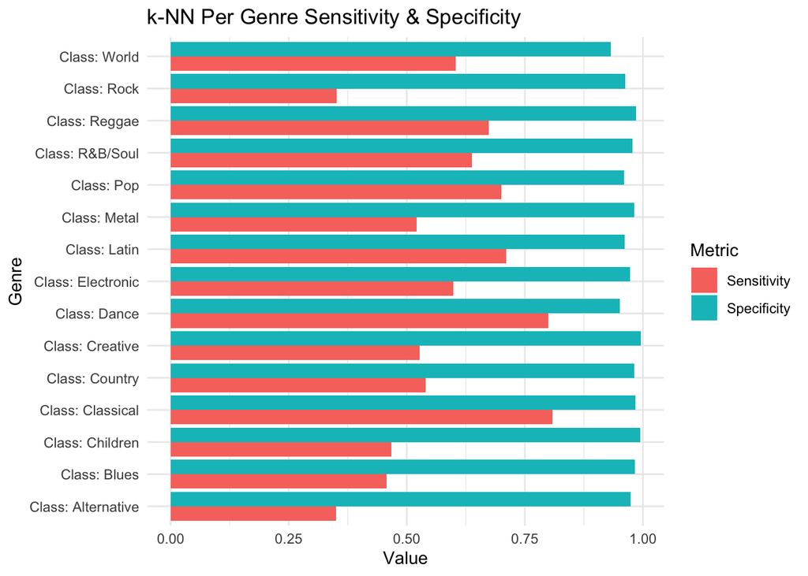

Overall, the **random forest model** was the best model for predicting the genre using features of the dataset. Genres with the lowest sensitivity were *rock, alternative,* and *blues*, however, these features are not sufficient to classify all genres, especially those that overlap stylistically like *rock, alternative,* and *metal*.

| Model | Accuracy | Kappa | Sensitivity | Specificity |
| --- | --- | --- | --- | --- |
| Full | 0.3179271 | 0.2327558 | 0.2376594 | 0.9488335 |
| Stepwise | 0.3447642 | 0.2570058 | 0.2610710 | 0.9502957 |
| RandomForest | 0.7046667 | 0.6696667 | 0.6404744 | 0.9777946 |
| kNN | 0.6365079 | 0.5971736 | 0.5832230 | 0.9733181 |

# RESULTS: Question 2

For the second question, we wanted to determine which variables affected popularity the most based on genres. We chose a couple of different models to help figure out which variables affected the popularity the most. A **full linear regression model** served as a baseline model that we could compare with the rest of the models. In other words, it acted as a control to see how all variables (features) impact popularity. A **reduced linear regression model** (removing 1 variable at a time) was also used to test the individual importance of a variable. By removing a singular variable, we can understand the weight that a variable has in helping to predict *popularity*. Finally, we used an *interaction model* to see how the specific genre affects the variables and popularity without assuming that every feature acts the same across all genres. For the first two linear models, we calculated the root mean squared error (RMSE), mean absolute error (MAE), and the mean bias error (MB) to give us important information about the prediction accuracy and whether our models were overfitting the dataset. These error metrics were used in the **full linear model** to evaluate the model’s accuracy and bias to ensure that the linear model was appropriate to use. The error metrics were then used to visualize the importance of the individual variables. If a removed variable were to increase the RMSE or MAE, we would know that the specific music feature contributed to predicting a song’s popularity within a specific genre.

The results of the **full linear model** showed that the model did not over- or under-predict based on the MB of zero across all genres. The RMSE and MAE spikes are based on the genre that it is predicting. This is the reason that we chose to include the **interaction model**, so that we can see how the variables interact with popularity specific to the genre, as the variables do not act the same across all genres.

Of the models that we created, the connected dot plots for the reduced linear model were the most important visualization in answering our overall question. The upward spikes in these graphs tell us which variables are important for predicting the popularity of a certain genre. Looking at the RMSE plot, we can see several noticeable spikes that indicate which variables impact the popularity of a track within a certain genre. In the dance genre, for example, when the *loudness* variable is removed (“*no-loudness*”), there is a significant upward spike in the RMSE value, indicating that this variable is important in determining the popularity of a track that falls under the dance genre. For the *electronic* genre, *instrumentalness* is the key variable according to RMSE changes. For the *country* genre, *valence* is the key variable. *Instrumentalness* and *speechiness* are the important variables in the *world* genre. For the *blues* genre, *speechiness* and *valence* are the determining variables. *Speechiness* is the variable for the genre of *children*. For the *metal* genre, *danceability* is the most important variable. Finally, for the *classical* genre, *acousticness* is the key variable. Looking at the MAE plot, we can again take notice of the significant spikes, which indicate variable importance in determining popularity for the genre in question. *Dance* is most heavily influenced by *loudness* and *valence*, while the popularity of a *pop* track is determined heavily by *danceability* and *instrumentalness*. The *electronic* genre is also decided by *instrumentalness*, and *valence* plays a big role in the *classical* genre. Both the *world* genre and *Latin* are affected by *instrumentalness*. *Speechiness* and *valence* are the key variables for the *blues* genre. *Speechiness* also determines the popularity of a track in the *children’s* genre. Finally, *danceability* and *instrumentalness* are the key variables of the *metal* genre. While RMSE and MAE indicate overall prediction accuracy, MB focuses on identifying systematic overestimation or underestimation. Therefore, we cannot use the MB plot to directly determine which variables are most important for predicting popularity. However, looking at the MB plot, one unusual result we noticed was the influence of the *time signature* variable on the *world* genre. The removal of this musical feature had a massive, positive impact on the mean bias value. In every model with this variable, the models are underpredicting (negative MB). Yet, when this variable is removed, the model is overestimating (positive MB). The spike on the graph is significantly larger than any other spike across all three connected dot plots, and we found this to be very interesting. Since the removal of the *time signature* variable had a negligible impact on the RMSE and MAE values for the world genre, we can determine that this variable does not impact the accuracy of the model, but rather only its bias.

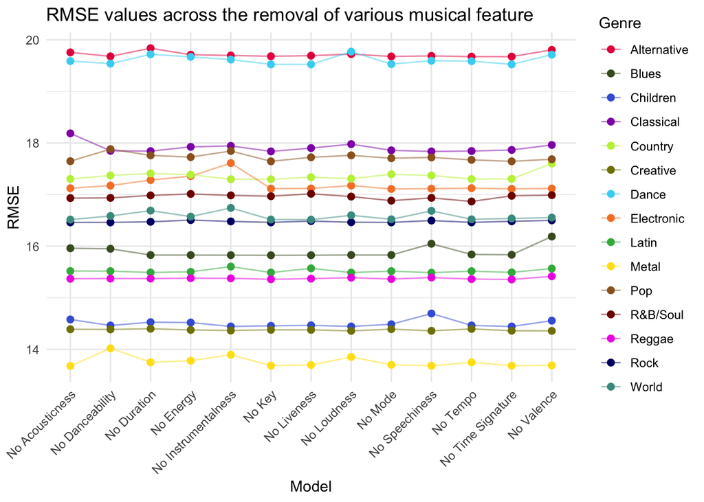

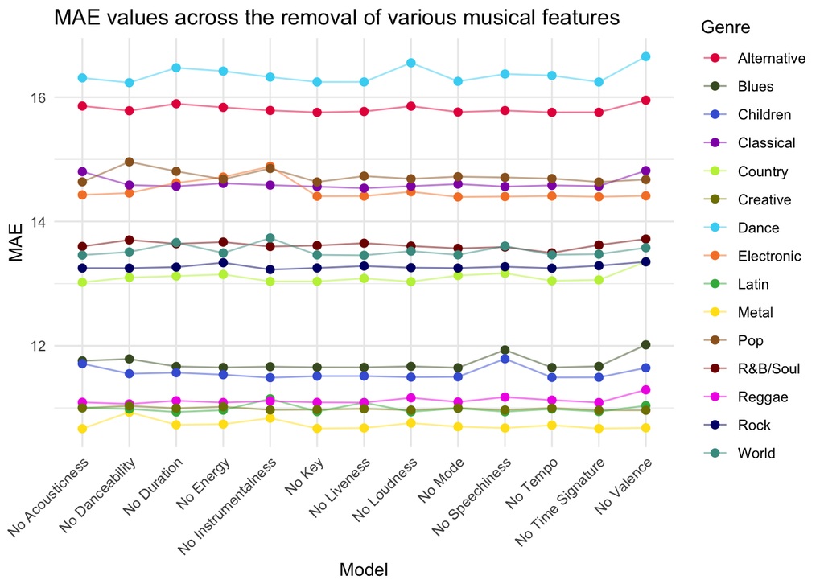

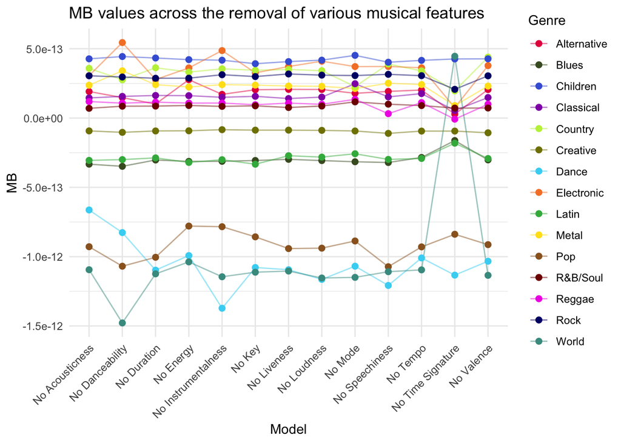

The final visualization is an **interactive model** of the most important variables across all genres. Through **cross-fold validation**, we created estimates and p-values for every relationship between a genre and a variable. From there, we filtered the results to only include statistically significant p-values, less than or equal to 0.05, and added all these data points onto a scatter plot. What makes this scatter plot particularly intriguing is its interactivity. By scrolling your mouse over each data point, you are provided with a more detailed look. A more precise p-value and estimate are shown along with the name of the connection (Genre-variable). Overall, this scatterplot demonstrates the most important genre-variable relationships in this dataset by displaying all statistically significant relationships and arranging them so they can be viewed by the strength of their relationship.

[interactive chart not shown]

# CONCLUSION

Throughout this paper, we have attempted to investigate two primary questions:

1. **Which classification model best predicts genre using features of the dataset?**
2. **How can we best predict a track’s popularity based on its genre and other music features?**

The findings of this paper could potentially change the way music could potentially be marketed. Historically, *genre* served as a primary indicator for listener preference and how music would be marketed. This can be seen with the prevalence of *pop* music and, more recently, *hip-hop*. *Hip-hop*, especially, has in the past 20 years become marketed with popularity similar to *pop* music. The results of this paper provide more measurable music features for the genres that can be very predictive of a song’s popularity. This could change the way music is not only marketed, but also created and distributed. Musicians, artists, and producers could benefit by making songs with audio profiles that line up with listener preferences rather than genre expectations. For example, the *children’s* music genre’s primary indicator of popularity is *speechiness*, so to make a song that is more popular, there could be a higher focus on a vocal melody rather than on the instrumental of the song. Marketing and recommendations from streaming services can also use these more specific listening preferences to promote songs that are aligned with specific listeners’ music feature similarities, rather than genres, for their algorithms, rather than to make recommendations based on genres. This could also extend to the way playlists are curated, adjusting to real-time changes in listener preferences related to track features rather than purely genre changes. The findings of this paper give more options, along with track genres, to look at the popularity of music, and a way that recommendation algorithms for streaming services can adapt to other features of music.

This research could be further expanded on in the future by using datasets that incorporate more user data, like *skips, replays, saves, playlist additions, and sharing activity*. This information would provide more holistic information on a song, and what features drive lasting popularity rather than temporary success. This information could also help see if a specific portion of a song is more popular than the rest of it, and see which audio features are in that snippet of the song that is getting popular, and recommend other songs with those same audio features. On a modeling level, more non-linear and machine learning techniques, such as neural networks, would be able to see interactions between features and genres that linear models would overlook. Keeping the original genre specificity along with using more complex learning techniques would give us the ability to see potential interactions in audio features with more niche genres, making predictive models more accurate. Acquiring more temporal data of a song’s popularity, along with other features or genre popularity during the time a song was also popular, to determine popularity trends, better gauge listener tastes, and virality. Future research including these potential expansions would allow for more extensive frameworks for predicting a song’s popularity, and this information would help artists, producers, and marketers forecast a piece of music’s success. Our questions helped us understand that a piece of music’s popularity lies outside of simply genre, and encourages further exploration of the many different factors of its popularity.